# Masking

[video not shown]

Post-processing doesn’t always mean altering the entire screen. In our dissolve tutorial, we looked at using a mask to control how the object would dissolve by applying a noise texture or gradient to manipulate the shader. Screen shaders can do that too.

Let’s set up a simple X-ray shader as an example. It uses multiple viewports and a mask.

## Setting the scene up

We need three viewports: what you see when the X-ray isn’t on, what the x-ray reveals, and what shape the X-ray is. We’ll be combining three textures in one final shader so we’ll use viewport textures.

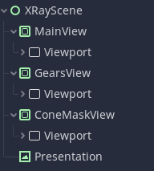

### Main View

The *MainView* is where you’d keep your gameplay scene and actors.

In our example, the *MainView* has a simple scene as a child of the *Viewport* named *MainScene*. It only has a sprite and a point of origin for our X-ray scope which is animated using an animation player.

We also use `RemoteTransform2D` nodes which control the position of objects in the *XRayView*. These synchronize our two worlds together across different viewports by giving them paths to another node in the hierarchy.

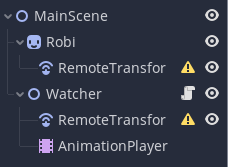

### XRay View

The x-ray view has everything you see when underneath the mask.

In our example, we just have an animated gear train. The `RemoteTransform2D` which controls its position is a child of the *Robi* sprite in the *MainScene*.

To have both the *MainView* and the *XRayView* visible inside the x-ray area, turn on the *Viewport*’s *Transparent Bg* property. Otherwise, you’ll replace the main view entirely, and the background color will be part of the texture.

### Mask View

Masks that have one purpose are typically black and white images. The mask view shows only where the mask is white, and hides itself where it’s black.

Our example consists of a single `Node2D` that implements `_draw()` to draw a white cone pointed to the right named *Cone*. It’s a child of the *MaskView* *Viewport*. Making it’s script a tool shows it in the editor.

```
tool
extends Node2D

func _draw() -> void:
    draw_polygon(
        [Vector2.ZERO, Vector2(2000, 500), Vector2(2000, -500)], [Color.white]
    )
```

The `RemoteTransform2D` attached to the *Watcher* in the *MainView* controls the *Cone*’s position and rotation.

*Note: The other way of making the viewport’s background black is to have a full screen black `ColorRect` as the top most node.*

### Presentation

The `TextureRect` is where we bring it all together. If you recall, we named it *Presentation*.

Add a new `ShaderMaterial` and assign it a new `Shader`. Save it to your filesystem as `xray_mask.shader`.

We need space for the x-ray and mask textures, so declare those two uniforms.

```
shader_type canvas_item;

uniform sampler2D alternate_viewport;
uniform sampler2D mask_viewport;
```

Dimming the rest of the screen helps contrast where the scope is highlighting. We’ll control how dark it should get with another uniform with a range from 0% to 100% dimmed.

[figure not shown]

```
uniform float dim_main_view : hint_range(0, 1) = 0.2;
```

The first step is to sample all three textures because they have all the information we need. The mask is black and white, so we extract one of the colors - red in this case - and have it as a floating point value instead of a color.

```
void fragment() {
    vec4 main_color = texture(TEXTURE, UV);
    float mask_color = texture(mask_viewport, UV).r;
    vec4 alternate_color = texture(alternate_viewport, UV);
}
```

To figure out the final color, we need to decide on the output:

- Where the mask isn’t, it should be the main color, but darker.
- Where the mask and the alternate color both co-exist, it should be the alternate color.
- Where the mask is but where there is no alternate color, it should be the main color.

We can use basic math to get this result. First, we calculate the darker main color where the mask isn’t. The mask is between `0.0` and `1.0`, so we invert it with `1.0 - mask_color`, and multiply it with the main color. Everything being dim is done by building a color and multiplying it with the mask inverse.

This might bring parts of the color to below `0`, so we’ll clamp it at the very end.

```
vec4 out_color = main_color * (1.0 - mask_color);
vec4 dim_color = vec4(vec3(dim_main_view), 0.0) * (1.0 - mask_color);

COLOR = clamp(out_color - dim_color, 0, 1);
```

We then add the alternate color to the main color.

```
out_color += alternate_color * mask_color;
```

But we *also* want to show the main color and not replace it. To do this we only mask where the alternate color exists. Since it’s a transparent texture, we can use the alpha for that. Instead of taking the inverse of the mask, we take the inverse of the product of the alternate color’s alpha and the mask.

```
vec4 out_color = main_color * (1.0 - alternate_color.a * mask_color);
```

Which brings the final code:

```
shader_type canvas_item;

uniform sampler2D alternate_viewport;
uniform sampler2D mask_viewport;
uniform float dim_main_view : hint_range(0, 1) = 0.2;

void fragment() {
    vec4 main_color = texture(TEXTURE, UV);
    float mask_color = texture(mask_viewport, UV).r;
    vec4 alternate_color = texture(alternate_viewport, UV);

    vec4 out_color = main_color * (1.0 - alternate_color.a * mask_color);
    out_color += alternate_color * mask_color;
    vec4 dim_color = vec4(vec3(dim_main_view), 0.0) * (1.0 - mask_color);

    COLOR = clamp(out_color - dim_color, 0, 1);
}
```